# Tutorial 3. Multi-omics Data Integration

Iguaracy Souza, Thodoris Koutsandreas, Umran Yaman

```r
suppressPackageStartupMessages({
    library(Signac)
    library(SingleCellExperiment)
    library(Seurat)
    library(ggplot2)
    library(ggpubr)
    library(cowplot)
    library(RColorBrewer)
})
```

### 1. Loading of the pre-processed snRNA-seq and snATAC-seq datasets.

```r
snRNA_qc_seurat_obj <- readRDS("../data/snRNA_qc_seurat_obj.rds")
snATAC_qc_seurat_obj <- readRDS("../data/snATAC_qc_seurat_obj.rds")
```

#### Cells in snRNA-seq data.

```r
dim(snRNA_qc_seurat_obj)
```

```
## [1] 16337 21196
```

```r
table(snRNA_qc_seurat_obj$major.celltype)
```

```
##
##                       Astrocytes               Excitatory_neurons
##                             3335                             3255
##               Inhibitory_neurons                        Microglia
##                             2822                             3494
## Oligodendrocyte_progenitor_cells                 Oligodendrocytes
##                             3408                             3326
##                         Vascular
##                             1556
```

#### Cells in snATAC-seq data.

```r
dim(snATAC_qc_seurat_obj)
```

```
## [1] 363775  13895
```

```r
table(snATAC_qc_seurat_obj$Celltype1)
```

```
##
##                       Astrocytes               Excitatory_neurons
##                             2176                             2401
##               Inhibitory_neurons                        Microglia
##                             2406                             2252
## Oligodendrocyte_progenitor_cells                 Oligodendrocytes
##                             2396                             1936
##                         Vascular
##                              328
```

### 2. Visualization of Cell Populations (Ground-Truth Annotation)

We will visualize the cells for both RNA and ATAC seq, based on the pre-defined cell type identities (derived from the original study), for exploratory reasons. The visualization of cell populations is performed using dimensionality reduction techniques (t-SNE or UMAP). These techniques help us to depict the cells in two dimensions, making it easier to identify distinct cell populations or clusters.

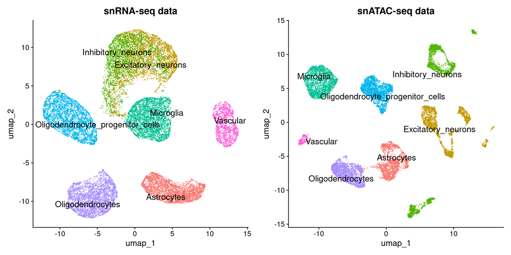

```r
RNA_plot <- DimPlot(snRNA_qc_seurat_obj, group.by = "major.celltype",
  label = TRUE, label.size = 5, repel = TRUE, pt.size = 0.01) +
  NoLegend() +
  ggtitle("snRNA-seq data")

ATAC_plot <- DimPlot(snATAC_qc_seurat_obj, group.by = "Celltype1",
  label = TRUE, , label.size = 5, repel = TRUE, , pt.size = 0.01) +
  NoLegend() +
  ggtitle("snATAC-seq data")

## Plot together
ggarrange(RNA_plot, ATAC_plot, ncol = 2, nrow = 1)
```

### 3. Integration and Normalization of the Gene Activities in the snATAC-seq Object

#### Integration

```r
gene_scores_obj <- readRDS("../data/initial_data/downsampled_snATAC_gene_scores_sumexp_obj.rds")
gene_names <- rowData(gene_scores_obj)$name

# Get the cell names from the snATAC-seq Seurat object and search for their
# records in the gene scores matrix
qc_cells <- colnames(snATAC_qc_seurat_obj)

# Before the subsetting
print(dim(gene_scores_obj))
```

```
## [1] 24919 22198
```

```r
gene_scores_obj <- gene_scores_obj[, qc_cells]
# After the subsetting
dim(gene_scores_obj)
```

```
## [1] 24919 13895
```

```r
# Integrate the gene scores matrix
gene_score_matrix <- assay(gene_scores_obj, "GeneScoreMatrix")
rownames(gene_score_matrix) <- gene_names
snATAC_qc_seurat_obj[["ACTIVITY"]] <- CreateAssayObject(counts = gene_score_matrix)
```

```r
gene_scores_obj <- NULL
gene_score_matrix <- NULL
gc()
```

```
##             used   (Mb) gc trigger    (Mb)   max used    (Mb)
## Ncells  10873445  580.8   15818034   844.8   15818034   844.8
## Vcells 987346004 7532.9 1806068801 13779.3 1463808456 11168.0
```

#### Normalization

```r
DefaultAssay(snATAC_qc_seurat_obj) <- "ACTIVITY"
snATAC_qc_seurat_obj <- NormalizeData(snATAC_qc_seurat_obj)
snATAC_qc_seurat_obj <- ScaleData(snATAC_qc_seurat_obj, features = rownames(snATAC_qc_seurat_obj))
```

#### Plot cell type markers’ activities (SPI1 - Microglia and GFAP - Astrocytes)

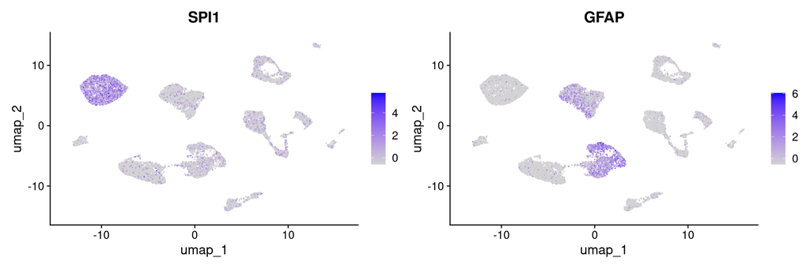

```r
FeaturePlot(
  object = snATAC_qc_seurat_obj,
  features = c("SPI1", "GFAP"),
  pt.size = 0.1,
  slot = "scale.data",
  ncol = 2)
```

### 4. Identification of Anchors Between the snRNA- & snATAC-seq Data

By identifying anchors, we can find shared cell types identities or states between the two omics datasets. This step is used to integrate information across modalities and relate the gene expression profiles to the chromatin accessibility ones.

The RNA-seq data wiil be used to annotate the cell types in ATAC-seq. Two tasks will be performed:

1. Detection of transfer anchors between the RNA- and ATAC-seq data.
2. Annotation of snATAC-seq cells using label transfer.

```r
# FindTransferAnchors(), TransferData() and AddMetaData() functions are used
# from Seurat

# Find the anchors using the most variable features in the snRNA-seq data
transfer.anchors <- FindTransferAnchors(reference = snRNA_qc_seurat_obj,
  query = snATAC_qc_seurat_obj,
  features = VariableFeatures(snRNA_qc_seurat_obj),
  reference.assay = "RNA",
  query.assay = "ACTIVITY",
  reduction = "cca")

# ATAC-seq cells annotation
predictions <- TransferData(anchorset = transfer.anchors,
  refdata = snRNA_qc_seurat_obj$major.celltype,
  weight.reduction = snATAC_qc_seurat_obj[["lsi"]],
  dims = 2:30)
print(head(predictions))
```

```
##                                                  predicted.id
## D19-12999#AGGCCCATCCTCCATG-1                       Astrocytes
## D19-12514#TTACCGCAGCTCCATA-1                       Astrocytes
## D19-13166#TGATTTCGTAACGGAC-1 Oligodendrocyte_progenitor_cells
## D19-12536#GCCTAGGCAGTATCTG-1                       Astrocytes
## D19-13160#TAGCATGGTCGAGGAT-1                 Oligodendrocytes
## D19-13000#TAATCGGTCATCGCAA-1                       Astrocytes
##                              prediction.score.Oligodendrocyte_progenitor_cells
## D19-12999#AGGCCCATCCTCCATG-1                                         0.0000000
## D19-12514#TTACCGCAGCTCCATA-1                                         0.0000000
## D19-13166#TGATTTCGTAACGGAC-1                                         0.4422213
## D19-12536#GCCTAGGCAGTATCTG-1                                         0.0000000
## D19-13160#TAGCATGGTCGAGGAT-1                                         0.0000000
## D19-13000#TAATCGGTCATCGCAA-1                                         0.0000000
##                              prediction.score.Excitatory_neurons
## D19-12999#AGGCCCATCCTCCATG-1                          0.00000000
## D19-12514#TTACCGCAGCTCCATA-1                          0.02764316
## D19-13166#TGATTTCGTAACGGAC-1                          0.25937421
## D19-12536#GCCTAGGCAGTATCTG-1                          0.00000000
## D19-13160#TAGCATGGTCGAGGAT-1                          0.02137723
## D19-13000#TAATCGGTCATCGCAA-1                          0.00000000
##                              prediction.score.Microglia
## D19-12999#AGGCCCATCCTCCATG-1                 0.00000000
## D19-12514#TTACCGCAGCTCCATA-1                 0.00000000
## D19-13166#TGATTTCGTAACGGAC-1                 0.06543557
## D19-12536#GCCTAGGCAGTATCTG-1                 0.00000000
## D19-13160#TAGCATGGTCGAGGAT-1                 0.00000000
## D19-13000#TAATCGGTCATCGCAA-1                 0.00000000
##                              prediction.score.Inhibitory_neurons
## D19-12999#AGGCCCATCCTCCATG-1                           0.0000000
## D19-12514#TTACCGCAGCTCCATA-1                           0.0000000
## D19-13166#TGATTTCGTAACGGAC-1                           0.1496075
## D19-12536#GCCTAGGCAGTATCTG-1                           0.0000000
## D19-13160#TAGCATGGTCGAGGAT-1                           0.0000000
## D19-13000#TAATCGGTCATCGCAA-1                           0.0000000
##                              prediction.score.Oligodendrocytes
## D19-12999#AGGCCCATCCTCCATG-1                         0.0000000
## D19-12514#TTACCGCAGCTCCATA-1                         0.0000000
## D19-13166#TGATTTCGTAACGGAC-1                         0.0000000
## D19-12536#GCCTAGGCAGTATCTG-1                         0.0000000
## D19-13160#TAGCATGGTCGAGGAT-1                         0.9786228
## D19-13000#TAATCGGTCATCGCAA-1                         0.0000000
##                              prediction.score.Astrocytes
## D19-12999#AGGCCCATCCTCCATG-1                  1.00000000
## D19-12514#TTACCGCAGCTCCATA-1                  0.97235684
## D19-13166#TGATTTCGTAACGGAC-1                  0.03579725
## D19-12536#GCCTAGGCAGTATCTG-1                  1.00000000
## D19-13160#TAGCATGGTCGAGGAT-1                  0.00000000
## D19-13000#TAATCGGTCATCGCAA-1                  1.00000000
##                              prediction.score.Vascular prediction.score.max
## D19-12999#AGGCCCATCCTCCATG-1                0.00000000            1.0000000
## D19-12514#TTACCGCAGCTCCATA-1                0.00000000            0.9723568
## D19-13166#TGATTTCGTAACGGAC-1                0.04756408            0.4422213
## D19-12536#GCCTAGGCAGTATCTG-1                0.00000000            1.0000000
## D19-13160#TAGCATGGTCGAGGAT-1                0.00000000            0.9786228
## D19-13000#TAATCGGTCATCGCAA-1                0.00000000            1.0000000
```

```r
snATAC_qc_seurat_obj <- AddMetaData(snATAC_qc_seurat_obj, metadata = predictions,
  col.name = c("predicted.id", "prediction.score.max"))
```

### 5. Comparison of Predicted & Ground-Truth Cell Type Annotations

In this step, after predicting cell type annotations for the snATAC-seq dataset, we compare them with the ground-truth annotations to assess the performance of the integration method. This step is to validate the accuracy of the integration and identify any discrepancies or misclassifications.

```r
# Make a new binary (TRUE - FALSE) column in metadata
predicted <- snATAC_qc_seurat_obj$predicted.id
true <- snATAC_qc_seurat_obj$Celltype1
snATAC_qc_seurat_obj$correct_annotation <- predicted == true

# Accuracy
ratio <- sum(snATAC_qc_seurat_obj$correct_annotation)/dim(snATAC_qc_seurat_obj)[2]
print(ratio)
```

```
## [1] 0.9769701
```

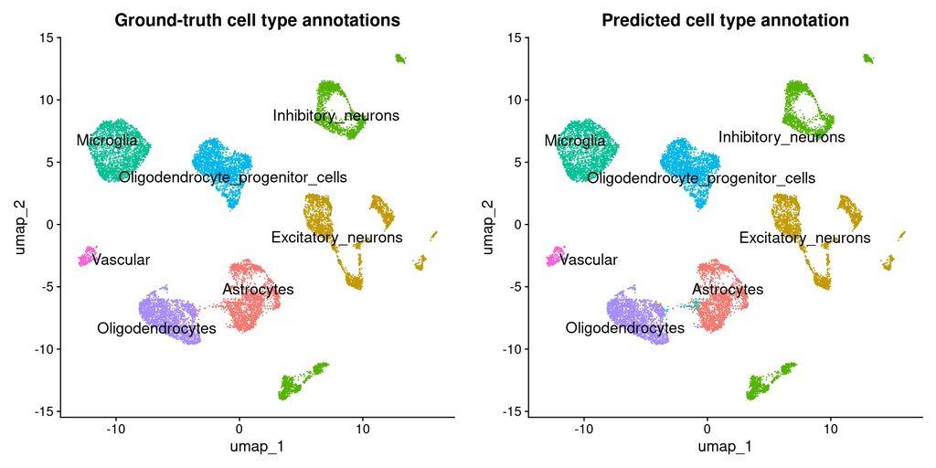

```r
# Plot the ground truth and predicted cell type annotations
plot_for_ground_truth <- DimPlot(snATAC_qc_seurat_obj, group.by = "Celltype1",
  label = TRUE, label.size = 5, repel = TRUE,
  pt.size = 0.01) +
  NoLegend() + ggtitle("Ground-truth cell type annotations")

plot_for_predictions <- DimPlot(snATAC_qc_seurat_obj, group.by = "predicted.id",
  label = TRUE, label.size = 5, repel = TRUE,
  pt.size = 0.01) +
  NoLegend() + ggtitle("Predicted cell type annotation")

## Plot together
ggarrange(plot_for_ground_truth, plot_for_predictions, ncol = 2, nrow = 1)
```

### 6. Exploration of Cell Type Predictions for the snATAC-seq Data

Using the following commands, we can visualize the agreement between the predicted and ground-truth cell type annotations and plot the density of prediction scores. Finally the predicted cellular landscape is created to depict the inconsistencies between the two cell type annotations.

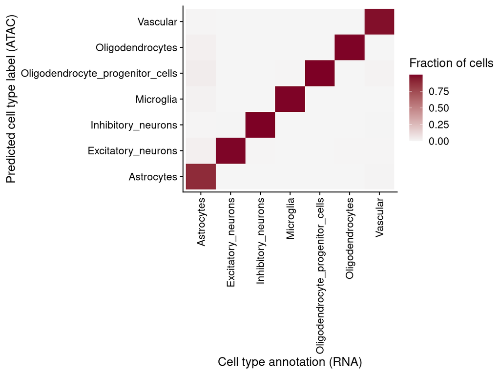

```r
# Plot 1: Agreement scores between ground truth and predicted annotations
predictions_df <- table(snATAC_qc_seurat_obj$Celltype1, snATAC_qc_seurat_obj$predicted.id)
predictions_df <- predictions_df / rowSums(predictions_df)
predictions_df <- as.data.frame(predictions_df)

ggplot(predictions_df, aes(Var1, Var2, fill = Freq)) +
  geom_tile() +
  scale_fill_gradient(name = "Fraction of cells", low = "#f5f5f5", high = "#7d0025") +
  xlab("Cell type annotation (RNA)") +
  ylab("Predicted cell type label (ATAC)") +
  theme_cowplot() +
  theme(axis.text.x = element_text(angle = 90, vjust = 0.5, hjust = 1))
```

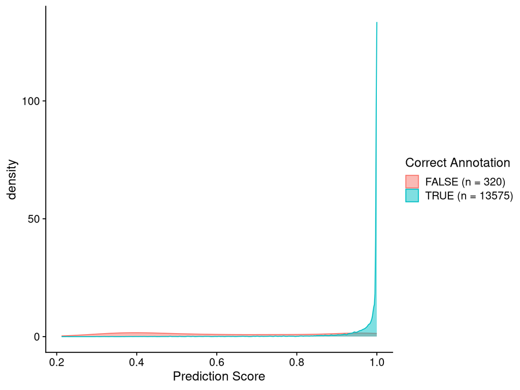

```r
# Plot 2: Distributions of correct and false classifications according to the prediction score
correct <- length(which(snATAC_qc_seurat_obj$Celltype1 == snATAC_qc_seurat_obj$predicted.id))
incorrect <- length(which(snATAC_qc_seurat_obj$Celltype1 != snATAC_qc_seurat_obj$predicted.id))
data <- FetchData(snATAC_qc_seurat_obj, vars = c("prediction.score.max", "correct_annotation"))

ggplot(data, aes(prediction.score.max, fill = correct_annotation, colour = correct_annotation)) +
  geom_density(alpha = 0.5) + theme_cowplot() +
  scale_fill_discrete(name = "Correct Annotation",
    labels = c(paste0("FALSE (n = ", incorrect, ")"),
      paste0("TRUE (n = ", correct, ")"))) +
  scale_color_discrete(name = "Correct Annotation",
    labels = c(paste0("FALSE (n = ", incorrect, ")"),
      paste0("TRUE (n = ", correct, ")"))) +
  xlab("Prediction Score")
```

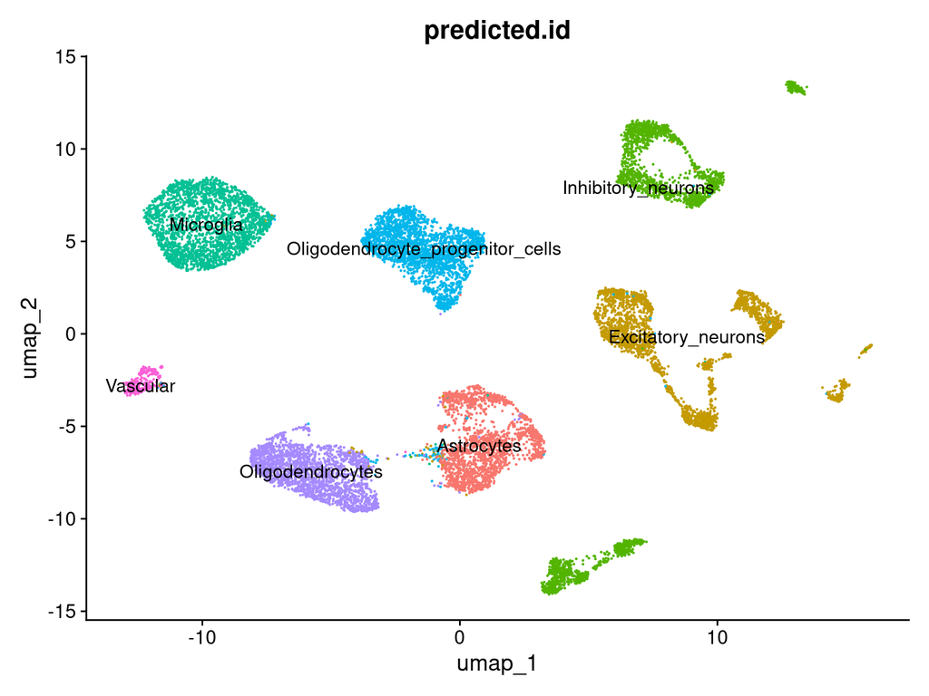

```r
# Plot 3: UMAP plot of cell type clusters using the predicted annotations for colors to highlight the inconsistencies.
DimPlot(object = snATAC_qc_seurat_obj, label = TRUE, group.by = "predicted.id") + NoLegend()
```